# R Notebook

Practical Evol Genomic - Sousa

```r
# load functions to run fastsimcoal2 and to process the output
source("utilFscFunctions.r")
source("ParFileInterpreter-VS1.r")

# create a list that saves all the required settings to run fastsimcoal2
settings <- list()
# path to fastsicoal2 executable file
settings$pathToFsc <- "./fastsimcoal2/fsc_linux64/"
# path to input files (working directory)
settings$pathTo_InputFile <- "./Henn_et_al_data/"
# path to TPL and EST file (tags)
settings$TPL_EST_file_tag <- "NoMig_San_Maya"
# number of coalescent simulations
settings$n_coalsims <- 100000
# number of optimization cycles
settings$n_cycles <- 20

# run fastsimcoal2
# run_fsc2(settings)

# get the command line to run fastsimcoal2
cmd <- get_fsc2_commandline(settings)
cmd
```

```
[1] "./fsc26  -t NoMig_San_Maya.tpl -e NoMig_San_Maya.est -L 20 -n 100000 -d -M -q -C1 -c2 -B2;"
```

fastsimcoal was invoked with the following command line arguments: fsc26.exe -t NoMig_San_Maya.tpl -e NoMig_San_Maya.est -L 20 -n 100000 -d -M -q -C1 -c2 -B2; Invalid number of batches (2;), setting it to default value of 12)

Random generator seed : 600945

No population growth detected in input file

Estimating model parameters using 12 batches and 2 threads

Estimation of parameters by conditional maximization via Brent algorithm (initial lhood = -479929)

Iter 1 Curr best params: 5343 29205 19586 3010 lhood=-477033

Iter 2 Curr best params: 5343 30117 19390 3010 lhood=-477018

Iter 3 Curr best params: 5343 30117 19390 2915 lhood=-477009

Iter 4 Curr best params: 5811 30864 19428 3162 lhood=-476954

Iter 5 Curr best params: 5811 30864 19428 3162 lhood=-476933

Iter 6 Curr best params: 5811 30864 19428 3162 lhood=-476933

Iter 7 Curr best params: 5811 30864 19428 3162 lhood=-476933

Iter 8 Curr best params: 6265 31606 19149 3375 lhood=-476889

Iter 9 Curr best params: 6469 31289 18766 3408 lhood=-476882

Iter 10 Curr best params: 6469 34154 18766 3408 lhood=-476875

Iter 11 Curr best params: 6469 34154 18766 3408 lhood=-476875

Iter 12 Curr best params: 6829 32513 19038 3521 lhood=-476875

Iter 13 Curr best params: 6829 32513 18581 3627 lhood=-476866

Iter 14 Curr best params: 6994 32513 18581 3699 lhood=-476858

Iter 15 Curr best params: 6994 32513 18581 3699 lhood=-476858

Iter 16 Curr best params: 6994 32513 18581 3699 lhood=-476858

Iter 17 Curr best params: 6994 32513 18581 3699 lhood=-476858

Iter 18 Curr best params: 6994 32513 18581 3699 lhood=-476858

Iter 19 Curr best params: 6994 32513 18581 3699 lhood=-476858

Iter 20 Curr best params: 6994 32513 18581 3699 lhood=-476858

Program total execution time: 220.853 seconds

```r
# read the file with the maximum likelihood estimates
maxlhoodEstimates <- read.table(paste(settings$pathTo_InputFile, "/",
                                      settings$TPL_EST_file_tag, "/",
                                      settings$TPL_EST_file_tag, ".bestlhoods",
                                      sep=""), header=T)
# look at the parameter estimates
maxlhoodEstimates
```

| NPOP1 | NPOP2 | NANC | TDIV | MaxEstLhood | MaxObsLhood |
| --- | --- | --- | --- | --- | --- |
| 6994 | 32513 | 18581 | 3699 | -476858.5 | -475819.9 |

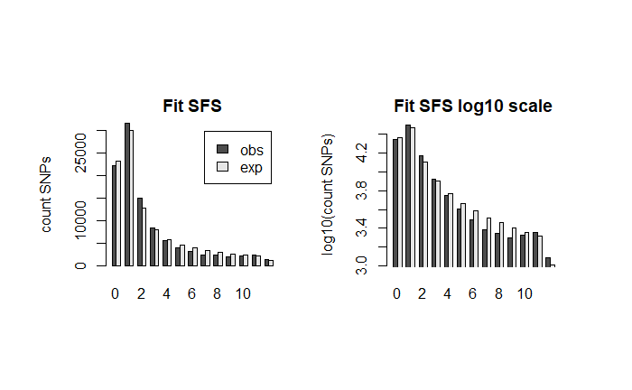

```r
# Read the observed SFS
obsfileend <- "_jointDAFpop1_0"
# 2D from two human populations: San and Maya
maya_san_2dsfs <- read.table(paste(settings$pathTo_InputFile, "/", settings$TPL_EST_file_tag, obsfileend,".obs",sep=""), skip=1, stringsAsFactors = F, header=T, row.names = 1)
# Read the expected SFS
expectedSFS <- read.table(paste(settings$pathTo_InputFile,
                    settings$TPL_EST_file_tag, "/",
                    settings$TPL_EST_file_tag, obsfileend, ".txt",
                    sep=""), header=T)

# discard the monomorphic sites from the observed SFS
pol_obs_2d <- as.matrix(maya_san_2dsfs)
# observed SFS just with SNPs (polymorphic sites)
pol_obs_2d[c(1,1)] <- 0
# get the marginal 1d sfs for pop 1
marginal1d_sfs <- rowSums(pol_obs_2d)
exp.marginal1d_sfs <- rowSums(expectedSFS)
# Plot the observed vs expected SFS
plot_fitSFS_1d(marginal1d_sfs, exp.marginal1d_sfs, c(1,max(marginal1d_sfs)*1.1), "San")
```

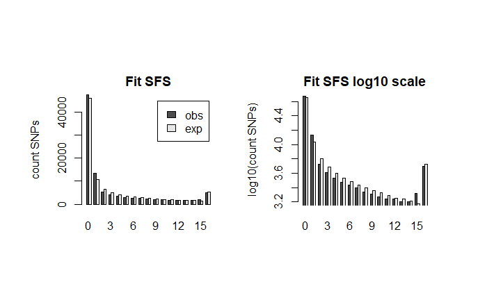

```r
# get the marginal 1d sfs for pop 2
marginal1d_sfs <- colSums(pol_obs_2d)
exp.marginal1d_sfs <- colSums(expectedSFS)
# Plot the observed vs expected SFS
plot_fitSFS_1d(marginal1d_sfs, exp.marginal1d_sfs, c(1,max(marginal1d_sfs)*1.1), "Maya")
```

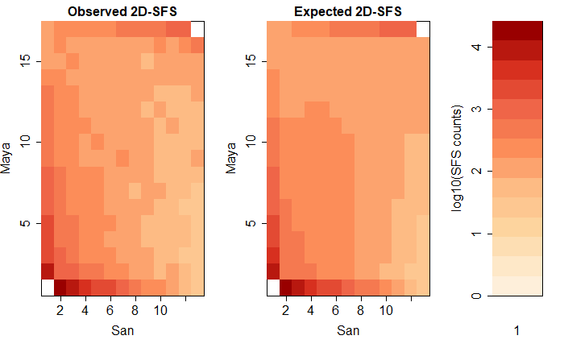

```r
# plot the fit of the 2D SFS
plot2dSFS(pol_obs_2d,expectedSFS,"San","Maya", 1)
```

```
[1] "./Henn_et_al_data/NoMig_San_Maya/NoMig_San_Maya_maxL"
```

```
Read 22 items
```

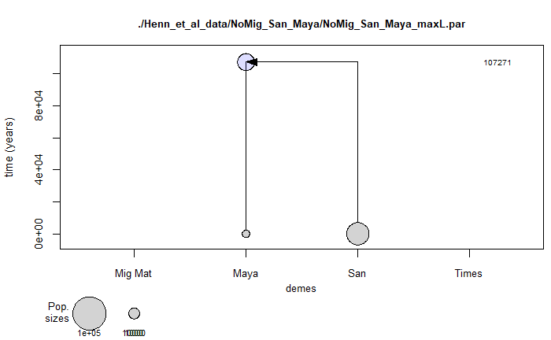

```r
# Draw a scenario of the model parameter estimates assuming a generation time of 29 years
# pdf(file=paste(settings$TPL_EST_file_tag,"_model.pdf", sep=""), width=8, height=10)
# path to the maxL.par file that is a par file with the parameters that maximize the likelihodo
path_to_maxL_file <- paste(settings$pathTo_InputFile, settings$TPL_EST_file_tag, "/",settings$TPL_EST_file_tag, "_maxL", sep="")
parFileInterpreter(args=path_to_maxL_file, pop.names=c("Maya","San"), gentime=29, printPDF=FALSE)
```

MaxObsLhood: is the maximum possible value for the likelihood if there was a perfect fit of the expected to the observed SFS, i.e. if the expected SFS was the relative observed SFS.

MaxEstLhood: is the maximum likelihood estimated according to the model parameters.

The better the fit, the smaller the difference between MaxObsLhood and MaxEstLhood